# Exercício 1

Henrique Capatto Ra 146406

# Geração de números aleatórios

Execução do primeiro exercício proposto

## Método da Inversão

O exercício em questão porpõe gerar números aleatórios que sigam a função densidade:

$$f_{X}(x) = \lambda e^{(-\lambda x)}, \forall x\in (0,\infty ), \forall \lambda\in (0,\infty )$$

Para gerar números aleatórios utilizando o **método da inversão**, precisamos:

```r
rexp2=function(n,lambda){

  unif01=runif(n)

  x = (-1/lambda)*(log(1-unif01))

  return(x)
}
n=1e3

lambda=10

amostra = rexp2(n,lambda)
```

A seguir, gráfico gerado, um histograma especificamente, a partir a amostra de tamanho 1000,sobreposto ao gráfico da função referida anteriormente.

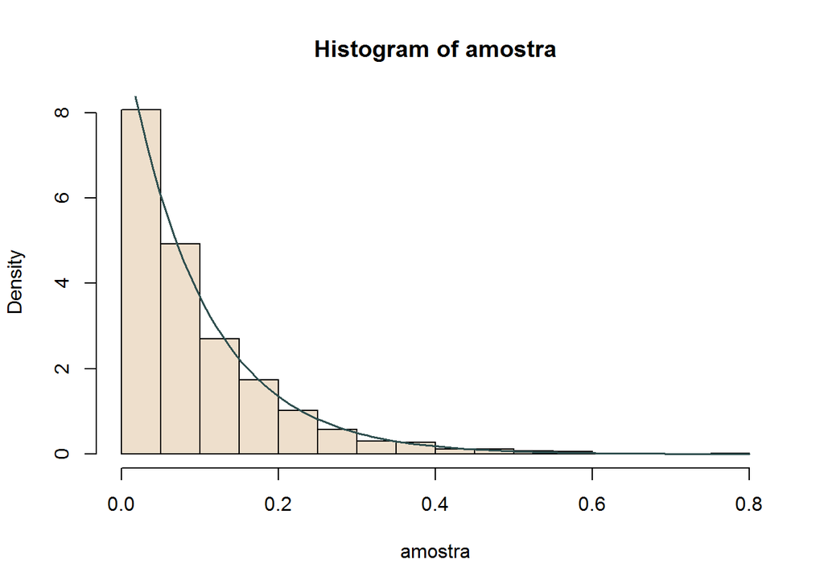

```r
hist(amostra,col="antiquewhite2",border="black",freq=FALSE)

curve(10*exp(-10*x),lw=1.5,col="darkslategray",add=TRUE)
```

O teste que se utilizará para validar a hipótese será o Chi-Quadrado de Aderência, possuinte do objetivo de testar a adeuqabilidade de um modelo probabilistico em relação a um conjunto de dados observados. Faremos o teste utilizando os quartis téoricos e os orginários da amostra aleatória. A hipótese nula é a de que a amostra segue a distribuição deseja. A alternativa, é a de que não segue.

Definição de $\alpha=$ 0.05

OS quartis teóricos desta distribuição são determinados pela pontos em que a função acumulada atinge os valores pré-especificada dos quantis(0.25,0.5,0.75).

Os resultados acima são respectivamente, 0.0288, 0.0693 e 0.1386.

```r
quartis = c(0,q1,q2,q3,1)

resTmp = cut(amostra, quartis, include.lowest=TRUE)

obs = as.integer(table(resTmp))

esp = rep(n/4, 4)

p_valor=chisq.test(cbind(obs, esp))[3]

prop.table(table(resTmp))
```

[output not shown]

O p-valor resultante é: 0.8983112

Logo, se p-valor for $<0.05$, rejeitar-se-á a hipótese nula. Caso contrário, não se preterirá.